# R and RStudio

Josh Day  
January 26, 2015

## Sources

- Hadley Wickham’s Books
  - [R Packages](http://r-pkgs.had.co.nz/)
  - [Advanced R](http://adv-r.had.co.nz/)
- Rcpp
  - [Rcpp.org](http://www.rcpp.org/)
  - [Rcpp Gallery](http://gallery.rcpp.org/)
  - [Boost](http://www.boost.org/)
  - [Armadillo](http://arma.sourceforge.net/)
- Debugging
  - [Debugging with RStudio](https://support.rstudio.com/hc/en-us/articles/200713843-Debugging-with-RStudio?version=0.98.1091&mode=desktop)
- Rmarkdown
  - [R Markdown](http://rmarkdown.rstudio.com/)
  - [Cheat Sheet](http://rmarkdown.rstudio.com/RMarkdownCheatSheet.pdf)
  - [knitr engine examples](http://yihui.name/knitr/demo/engines/)

## Outline

- R Packages
- Using C++ with R via `Rcpp`
- Profiling and Debugging
- `rmarkdown` and `knitr`

# R Packages

## Package Development

- Why create a package?
  - You won’t remember code you wrote last week, much less 5 years ago.
  - Adding documentation is easy (with `roxygen2`)
  - Share documented functions/data with collaborators

## Package Development

Things to make your life easier:

- `devtools`
  - Functions for development
- `roxygen2`
  - maintains `NAMESPACE` file, generates documentation from source code
- `testthat`
  - Framework for testing
- `knitr`
  - For making vignettes
- RStudio has great integration with GitHub

## Make your package

```r
# Get packages
install.packages(c("devtools", "roxygen2", "testthat", "knitr"))

# Check that everything is installed and functioning
devtools::has_devel()

# Create your package
devtools::create('path/to/myPackage')
```

That was easy.

## What Does `create()` Create?

- `DESCRIPTION`
  - metadata about the package (version, date, author, license, imports)
- `myPackage.Rproj`
  - Projects have a unique working directory, workspace, history, and source documents
- `NAMESPACE`
  - Can be confusing - ensures that your package won’t interfere with other packages.
  - Using `roxygen2` ensures you don’t have to edit this by hand
- `R/`
  - Stores your R code

## Other Directories You Might Want

- `src/`
  - Compiled code (to be discussed later)
- `inst/`
  - Installed files: Anything extra that should be installed with the package
    - `inst/CITATION`: how the package should be cited
  - Convention is for code from other languages to be put here
    - `inst/python`, `inst/ruby`, etc.
- `data/`
  - `devtools::use_data()`
  - Example data
  - Document with `roxygen2` (see Hadley’s [R Packages](http://r-pkgs.had.co.nz/) )
- `tests/`
  - `devtools::use_testthat()`

## How To Use [`roxygen2`](https://github.com/klutometis/roxygen/tags)

- First sentence is title of documentation
- Then add tags

```r
#' Update Bins for ASH estimator
#'
#' @param bin Object returned from \code{ash::bin1}
#' @param newdata Vector of new data
#'
#' @example inst/examples/ash_example.R
#'
#' @export
updateBin1 <- function(bin, newdata) { ...
```

- Use `roxygen2::roxygenize()` or `devtools::document()` to build documentation
- Build and Reload in RStudio

## What Does the `roxygen2` Block Produce?

```
% Generated by roxygen2 (4.1.0): do not edit by hand
% Please edit documentation in R/ash.R
\name{updateBin1}
\alias{updateBin1}
\title{Update Bins for ASH estimator}
\usage{
updateBin1(bin, newdata)
}
\arguments{
\item{bin}{Object returned from \code{ash::bin1}}

\item{newdata}{Vector of new data}
}
\description{
Update Bins for ASH estimator
}
\examples{
# Create two batches of data
y1 <- rnorm(100)
y2 <- rnorm(100)

# Create bins from the batch 1
mybin <- ash::bin1(y1, ab=c(-5, 5), nbin=50)

# Get ASH estimate and plot it
myash <- ash::ash1(mybin, m=5)
plot(myash, type="l")

# Update the bins with batch 2
mybin <- online::updateBin1(mybin, y2)

# update ASH estimate and plot it
myash <- ash::ash1(mybin, m=5)
plot(myash, type="l")
}
```

## What Does the `roxygen2` Block Produce?

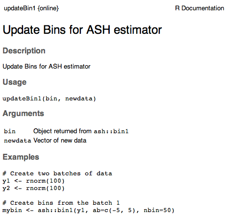

## A Useful Function from `devtools`

`devtools::install_github()`  
- Main argument is `repo`: accepts form `username/repo[/subdir][@ref|#pull]`

- Install package straight from github (can be based on specific reference)
  - Get updates before they are on CRAN
  - Get packages that aren’t available on CRAN (`runr`)

```r
# Get old release of devtools (Mac and Linux)
# For windows, see ?build_github_devtools
devtools::install_github("hadley/devtools@v1.6.1")

# Get latest release
devtools::install_github("hadley/devtools")
```

- See also: `install_bitbucket`, `install_svn`, `install_git`, `install_url`, `install_version`, `install_local`

# Rcpp

## Why use C++?

- Loops are slow in R
  - May be hard to vectorize
- Recursive functions
- Problems that require advanced data structures and algorithms that R doesn’t provide
- Avoid this:

[figure not shown]

source: [xkcd](http://imgs.xkcd.com/comics/efficiency.png)

## Use R’s High-Level Syntax in C++

- Rcpp provides a lot of syntactic “sugar” to ensure that C++ functions work very similarly to their R equivalents.
- All the basic arithmetic and logical operators are vectorized: `+`, `*`, `-`, `/`, `pow`, `<`, `<=`, `>`, `>=`, `==`, `!=`, `!`.
- Math functions: `floor()`, `cos()`, `gamma()`, `exp()`, etc.
- `r`/`d`/`p`/`q` for all standard distributions
- `apply` family
- [Rcpp-Sugar Vignette](http://cran.r-project.org/web/packages/Rcpp/vignettes/Rcpp-sugar.pdf)

## What you need

Rcpp:

- `install.packages('Rcpp')`

A working C++ compiler:

- Windows: [Rtools](http://cran.r-project.org/bin/windows/Rtools/)
- Mac: Xcode from app store
- Linux: `sudo apt-get install r-base-dev`

## Where To Start

- Does it work?

```r
library(Rcpp)
evalCpp("1+1")
```

```
## [1] 2
```

- [Gallery](http://gallery.rcpp.org/)

## Implement a Function in C++ from R

- The `cppFunction` function compiles C++ code and constructs an R wrapper
- C++ code needs specified types. Variables need to be initialized.

```r
library(Rcpp)
cppFunction('
int addTwo(int x, int y) {
  int sum = x + y;
  return sum;
}
')
addTwo(1, 2)
```

```
## [1] 3
```

```r
addTwo
```

```
## function (x, y)
## .Primitive(".Call")(<pointer: 0x10dbb8f50>, x, y)
```

## Be Careful About Data Types

```r
addTwo(1.9, 2.9)
```

```
## [1] 3
```

- Scalars:
  - `double`, `int`, `String`, `bool`
- Vectors:
  - `NumericVector`, `IntegerVector`, `CharacterVector`, `LogicalVector`
- Matrices:
  - `NumericMatrix`, `IntegerMatrix`, `CharacterMatrix`, `LogicalMatrix`
- Classes added by Rcpp:
  - `List`, `DataFrame`, `Function`, `Robject`

## Let’s fix this

Change output and inputs to `double`

```r
cppFunction('
double addTwo(double x, double y) {
  double sum = x + y;
  return sum;
}
')
addTwo(1.9, 2.9)
```

```
## [1] 4.8
```

## For Loop

- C++ Syntax: `for (init; condition; increment)`
- Indexing starts at 0!! (common source of bugs)

```r
sumR <- function(x) {
  n <- length(x)
  total <- 0
  for(i in 1:n) {
    total <- total + x[i]
  }
  return(total)
}

cppFunction('
  double sumC(NumericVector x) {
    int n = x.size();
    double total = 0;
    for(int i = 0; i < n; ++i) {
      total += x[i];
    }
    return total;
  }
')
```

## Timing Results for Sum Functions

```r
library(microbenchmark)
x <- runif(100000)
microbenchmark(
  sum(x),
  sumR(x),
  sumC(x)
)
```

```
## Unit: microseconds
##     expr       min         lq       mean     median         uq       max neval
##   sum(x)    92.346    93.0660   125.0484   119.6470   159.9960   242.799   100
##  sumR(x) 35399.752 38515.8395 47501.8216 45197.3530 52824.4470 93409.864   100
##  sumC(x)    88.390    94.8165   110.5784   102.1975   121.8925   223.940   100
```

## Example Using `NumericMatrix`

- Let’s write a function to create a diagonal matrix from a vector.
- Matrix values accessed by `A(i, j)`

```r
cppFunction('
NumericMatrix diagC(NumericVector x) {
  int n = x.size();

  NumericMatrix mat(n, n);

  for (int i = 0; i < n; i++) {
    mat(i, i) = x[i];
  }

  return mat;
}
')
```

## Timing Results for `diag()` Function

```r
microbenchmark(
  diag(1:1000),
  diagC(1:1000)
)
```

```
## Unit: milliseconds
##           expr      min       lq     mean   median       uq      max neval
##   diag(1:1000) 2.797329 2.863193 3.695875 2.909512 2.981942 42.10723   100
##  diagC(1:1000) 2.814742 2.886070 3.352609 2.929435 2.973619 43.85265   100
```

## Sourcing C++ Code From R

- Creating a new C++ file in RStudio sets you up with the necessary parts:

Your .cpp file needs to start with

[`#include <Rcpp.h>`](http://dirk.eddelbuettel.com/code/rcpp/html/Rcpp_8h_source.html)  
`using namespace Rcpp;`

and include the *Rcpp attribute*

`// [[Rcpp::export]]`

above any function you wish to be called from `R`.

- You can also include R code with special comments

## example1.cpp

```cpp
    #include <Rcpp.h>
    using namespace Rcpp;

    // [[Rcpp::export]]
    int timesTwo(int x) {
       return x * 2;
    }

    /*** R
    # test my function
    timesTwo(5)
    */
```

## Using C++ libraries other than Rcpp | Boost and Armadillo

- STL and Rcpp doesn’t get you far
- Thankfully, many libraries are available
  - Linear Algebra
    - RcppArmadillo
    - RcppEigen
  - Parallelization
    - RcppParallel
    - OpenMP (use attribute `// [[Rcpp::plugins(openmp)]]`)
  - Boost
    - Large collection of libraries

## Boost

- Large collection of peer-reviewed libraries
  - Some of which now included in C++11 Standard
- “…one of the most highly regarded and expertly designed C++ library projects in the world.”
  - Herb Sutter and Andrei Alexandrescu, [C++ Coding Standards](http://my.safaribooksonline.com/0321113586)
- Access Boost headers with R package `BH`
  - Use attribute `[[Rcpp::depends(BH)]]` in source

## Create Wrappers for Functions from the `boost/math` Library

```cpp
// We can now use the BH package
// [[Rcpp::depends(BH)]]

#include <Rcpp.h>
#include <boost/math/common_factor.hpp>

using namespace Rcpp;

// [[Rcpp::export]]
int computeGCD(int a, int b) {
    return boost::math::gcd(a, b);
}

// [[Rcpp::export]]
int computeLCM(int a, int b) {
    return boost::math::lcm(a, b);
}
```

## Use our new functions in R

```r
sourceCpp("examples/boost.cpp")
computeGCD(100, 75)
```

```
## [1] 25
```

```r
computeLCM(77, 55)
```

```
## [1] 385
```

## RcppArmadillo

http://arma.sourceforge.net/

- Syntax deliberately similar to [Matlab](http://arma.sourceforge.net/docs.html#syntax)
- Aims towards a good balance between speed and ease of use
- 100+ packages depend on RcppArmadillo
- OSX Mavericks needs some help before you can use Armadillo:
  - [Here is the explanation why](http://www.thecoatlessprofessor.com/programming/rcpp-rcpparmadillo-and-os-x-mavericks-lgfortran-and-lquadmath-error)
  - `curl -O http://r.research.att.com/libs/gfortran-4.8.2-darwin13.tar.bz2`
  - `sudo tar fvxz gfortran-4.8.2-darwin13.tar.bz2 -C /`

## RcppArmadillo

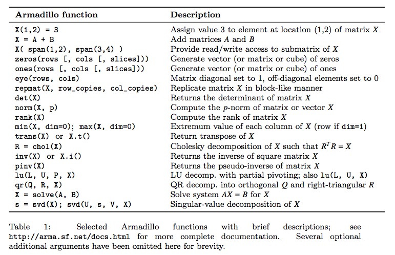

[Source](http://cran.r-project.org/web/packages/RcppArmadillo/vignettes/RcppArmadillo-intro.pdf)

## RcppArmadillo Inline Function

What if I want to use the Armadillo package for an inline function?

```r
cppFunction("
  arma::mat outerC(arma::colvec a, arma::rowvec b) {
    return a*b;
  }
", depends="RcppArmadillo")
outerC(1:3, 1:3)
```

```
##      [,1] [,2] [,3]
## [1,]    1    2    3
## [2,]    2    4    6
## [3,]    3    6    9
```

## RcppArmadillo Function from Source Code

- What if I want to source a .cpp file using Armadillo namespace? We need to add:  
  `#include <RcppArmadillo.h>`  
  `// [[Rcpp::depends(RcppArmadillo)]]`

```cpp
#include <RcppArmadillo.h>
// [[Rcpp::depends(RcppArmadillo)]]
using namespace Rcpp;

// [[Rcpp::export]]
arma::mat outerC2(arma::colvec a, arma::rowvec b) {
    return a*b;
  }

/*** R
outerC2(1:2, 1:2)
*/
```

## Timing Results for `outer` Functions

```r
x <- 1:100
y <- 2:101
microbenchmark(
  x %*% t(y),
  tcrossprod(x, y),
  outer(x, y),
  outerC(x, y),
  outerC2(x, y),
times=500)
```

```
## Unit: microseconds
##              expr    min      lq     mean  median      uq      max neval
##        x %*% t(y) 19.868 21.3725 39.61303 23.9575 26.3825 2707.918   500
##  tcrossprod(x, y) 14.511 15.7350 46.11585 18.1810 20.6580 3123.917   500
##       outer(x, y) 25.954 28.2730 42.76981 30.8770 37.9750 2447.929   500
##      outerC(x, y) 23.142 28.3365 56.75197 34.0020 37.3050 2709.220   500
##     outerC2(x, y) 23.264 28.2940 62.89900 33.9725 38.8245 3981.919   500
```

## Using C++ Code in a Package

- Run `devtools::use_rcpp()`
  - Among other things, this adds a `src/` folder for .cpp files
- You need to add a file with the following to `R/`

```r
#' @useDynLib your-package-name
#' @importFrom Rcpp sourceCpp
NULL
```

- In your .cpp files, you can use `roxygen2` tags like `` //` @export ``
- Building the package will create R wrappers and documentation for your C++ functions
  - `devtools::load_all()`
  - Cmd + Shift + B in RStudio

# Debugging and Profiling

## Debugging

- `traceback()`
  - prints the call stack, bottom to top
  - this shows where the error is
- `browser()`
  - examine objects as you run function line by line

## Breakpoints

- Breakpoints in RStudio
  - puts RStudio in debug mode: calls both `traceback()` and `browser()`

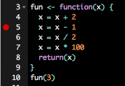

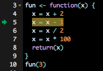

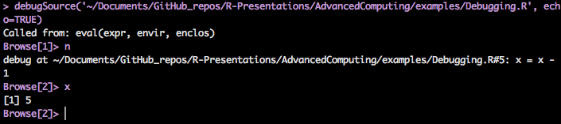

## Profiling

- `lineprof` package
  - `devtools::install_github("hadley/lineprof")`
  - Times are not exact. This is most useful for spotting bottlenecks
- Profiling.R

```r
library(lineprof)
f <- function() {
  pause(0.1)
  g()
  h()
}
g <- function() {
  pause(0.1)
  h()
}
h <- function() {
  pause(0.1)
}
```

## Profiling

```r
l <- lineprof(f())
l
```

```
## Reducing depth to 2 (from 5)
## Common path: <text>
```

```
##    time alloc release dups      ref     src
## 1 0.080 0.001       0    1 <text>#3 f/pause
## 2 0.161 0.002       0    0 <text>#4 f/g
## 3 0.079 0.000       0    0 <text>#5 f/h
```

```r
focus(l, "g")
```

```
## Reducing depth to 2 (from 4)
## Common path: <text>
```

```
##    time alloc release dups      ref     src
## 1 0.081 0.001       0    0 <text>#8 g/pause
## 2 0.080 0.001       0    0 <text>#9 g/h
```

# Rmarkdown

## Reproducible research with Rmarkdown

- Markdown is a text-to-HTML conversion tool
  - Easy to read, easy to write
- Rmarkdown is markdown with embedded code and output
- Generate report/code/figures from one file
- Rmarkdown files can generate
  - html (slides or report, can embed shiny apps)
  - PDF (beamer slides or report)
  - Word document
- Add equations with
  - Inline: `$y = x^2$`
  - Display: `$$y = x^2$$`

## Example

[figure not shown]

source: http://rmarkdown.rstudio.com/

## `knitr` Language Engines

- In code chunks, you are not limited to R
- Rmarkdown includes text output and syntax highlighting for:
  - python, bash, awk, ruby, Rcpp, SAS, julia with `runr`, and more
- To my knowledge, no graphics from other languages are supported.
- Note: `knitr` is not limited to markdown
  - LaTeX (R Sweave in RStudio), HTML
  - Code chunks have different syntax in LaTeX

## Publishing on RPubs

- Easily publish any RMarkdown report with RStudio to [RPubs.com](http://rpubs.com/)
- Warning: Your report is immediately made public
- This presentation was made in RStudio with RMarkdown and is hosted on RPubs